# Twitter US Airline Sentiment - Connie Ullas

## Problem Definition and Information

### Context

Sentiment analysis/classification, which involves monitoring emotions in conversations on social media platforms, has become a key strategy in social media marketing. Twitter is one social media company that possesses 330 million monthly active users and produces a lot of data through tweets. Listening to how customers feel about the product/service on Twitter allows companies to understand their audience, keep on top of what is being said about their brand and their competitors, and discover new trends in the industry.

### Objective

Given a tweet, build a Natural Language Processing model that can determine whether a tweet is positive, negative, or neutral.

### Key Questions

1. Is there a good NLP model to predict a customer's sentiment in a tweet?
2. What are the key words that determine a customer's sentiment?
3. What improvements can airlines make to keep customers positive?

### Data Information

Twitter data on airlines was scraped from February of 2015 and contributors were asked to first classify positive, negative, and neutral tweets, followed by categorizing negative reasons (such as "late flight" or "rude service"). A detailed data dictionary can be found below.

**Data Dictionary**

- tweet_id
- airline_sentiment
- airline_sentiment_confidence
- negativereason
- negativereason_confidence
- airline
- airline_sentiment_gold
- name
- negativereason_gold
- retweet_count
- text
- tweet_coord
- tweet_created
- tweet_location
- user_timezone

# ----------------------------------------------------------------------------------------

## Part 1: Overview of Data

```python
# Importing the required libraries

# To read and manipulate the data
import pandas as pd
pd.set_option('max_colwidth', None)
import numpy as np

# To visualise the graphs
import matplotlib.pyplot as plt
import seaborn as sns

# Helps to display the images
from PIL import Image

# Helps to remove the punctuation
import string

# Importing the NLTK library
import nltk

nltk.download('stopwords')    # Loading the stopwords
nltk.download('punkt')        # Loading the punkt module, used in Tokenization
nltk.download('omw-1.4')      # Dependency for Tokenization
nltk.download('wordnet')      # Loading the wordnet module, used in stemming and lemmatization

from nltk.corpus import stopwords

# Helps to visualize the wordcloud
from wordcloud import WordCloud, STOPWORDS, ImageColorGenerator

# Import contractions library.
!pip install contractions
import contractions

# Import Regex, string and unicodedata.
import re, string, unicodedata

# Import BeautifulSoup
from bs4 import BeautifulSoup

# Used in Stemming
from nltk.stem.porter import PorterStemmer

# Used in Lemmatization
from nltk.stem import WordNetLemmatizer

# For Bag of words
from sklearn.feature_extraction.text import CountVectorizer
# For TF-IDF
from sklearn.feature_extraction.text import TfidfVectorizer

# Helped to create train and test data
from sklearn.model_selection import train_test_split
# Import cross validation
from sklearn.model_selection import cross_val_score

# Importing the Random Forest model
from sklearn.ensemble import RandomForestClassifier

# Metrics to evaluate the model
from sklearn.metrics import accuracy_score, classification_report, confusion_matrix
```

```
     ━━━━━━━━━━━━━━━━━━━━━━━━━━━━━━━━━━━━━━━ 289.9/289.9 kB 6.0 MB/s eta 0:00:00
     ━━━━━━━━━━━━━━━━━━━━━━━━━━━━━━━━━━━━━━ 110.8/110.8 kB 15.9 MB/s eta 0:00:00
```

```python
# mount the drive
from google.colab import drive
drive.mount('/content/drive')
```

```python
# load the data
tweets = pd.read_csv("/content/drive/MyDrive/Data Science/PGP-MLAI/NLP/Tweets.csv")
```

```python
# Creating the copy of the data
data = tweets.copy()
```

```python
# Check a sample of the data to make sure it came in correctly
data.sample(n=5, random_state=1)
```

|  | tweet_id | airline_sentiment | airline_sentiment_confidence | negativereason | negativereason_confidence | airline | airline_sentiment_gold | name | negativereason_gold | retweet_count | text | tweet_coord | tweet_created | tweet_location | user_timezone |
| --- | --- | --- | --- | --- | --- | --- | --- | --- | --- | --- | --- | --- | --- | --- | --- |
| 8515 | 568198336651649027 | positive | 1.0000 | NaN | NaN | Delta | NaN | GenuineJack | NaN | 0 | @JetBlue I'll pass along the advice. You guys rock!! | NaN | 2015-02-18 16:00:14 -0800 | Massachusetts | Central Time (US & Canada) |
| 3439 | 568438094652956673 | negative | 0.7036 | Lost Luggage | 0.7036 | United | NaN | vina_love | NaN | 0 | @united I sent you a dm with my file reference number.. I just want to know if someone has located my bag even if it's not here yet. | NaN | 2015-02-19 07:52:57 -0800 | ny | Quito |
| 6439 | 567858373527470080 | positive | 1.0000 | NaN | NaN | Southwest | NaN | Capt_Smirk | NaN | 0 | @SouthwestAir Black History Commercial is really sweet. Well done. | NaN | 2015-02-17 17:29:21 -0800 | La Florida | Eastern Time (US & Canada) |
| 5112 | 569336871853170688 | negative | 1.0000 | Late Flight | 1.0000 | Southwest | NaN | scoobydoo9749 | NaN | 0 | @SouthwestAir why am I still in Baltimore?! @delta is doing laps around us and laughing about it. # ridiculous | [39.1848041, -76.6787131] | 2015-02-21 19:24:22 -0800 | Tallahassee, FL | America/Chicago |
| 5645 | 568839199773732864 | positive | 0.6832 | NaN | NaN | Southwest | NaN | laurafall | NaN | 0 | @SouthwestAir SEA to DEN. South Sound Volleyball team on its way! http://t.co/tN5cXCld6M | NaN | 2015-02-20 10:26:48 -0800 | NaN | Pacific Time (US & Canada) |

- Looks like all the features came in.
- There are positive and negative sentiments shown in the sample.
- There are some missing/null values in some of the columns.

```python
# check the shape
print(f"There are {data.shape[0]} rows and {data.shape[1]} columns in the data.")
```

```
There are 14640 rows and 15 columns in the data.
```

```python
# check for duplicates
print(f"There are {data.duplicated().sum()} duplicated rows in the data.")
```

```
There are 36 duplicated rows in the data.
```

```python
# dropping the duplicates
df = data.drop_duplicates(keep = 'first')

# checking for duplicate values
df.duplicated().sum()
```

```
0
```

```python
# resetting the index of the dataframe
df = df.reset_index(drop = True)
```

```python
# check datatypes of the columns and which columns have null values
df.info()
```

```
<class 'pandas.core.frame.DataFrame'>
RangeIndex: 14604 entries, 0 to 14603
Data columns (total 15 columns):
 #   Column                        Non-Null Count  Dtype
---  ------                        --------------  -----
 0   tweet_id                      14604 non-null  int64
 1   airline_sentiment             14604 non-null  object
 2   airline_sentiment_confidence  14604 non-null  float64
 3   negativereason                9159 non-null   object
 4   negativereason_confidence     10503 non-null  float64
 5   airline                       14604 non-null  object
 6   airline_sentiment_gold        40 non-null     object
 7   name                          14604 non-null  object
 8   negativereason_gold           32 non-null     object
 9   retweet_count                 14604 non-null  int64
 10  text                          14604 non-null  object
 11  tweet_coord                   1015 non-null   object
 12  tweet_created                 14604 non-null  object
 13  tweet_location                9881 non-null   object
 14  user_timezone                 9790 non-null   object
dtypes: float64(2), int64(2), object(11)
memory usage: 1.7+ MB
```

```python
# check which columns have null values
df.isna().sum()[df.isna().sum() > 0]
```

```
negativereason                5445
negativereason_confidence     4101
airline_sentiment_gold       14564
negativereason_gold          14572
tweet_coord                  13589
tweet_location                4723
user_timezone                 4814
dtype: int64
```

**Observations:**

- Data has 14604 rows after dropping duplicates.
- There are 2 float type columns, 2 integer type columns, and 11 object type columns.
- There are null values present in negativereason, negativereason_confidence, airline_sentiment_gold, negativereason_gold, tweet_coord, tweet_location, and user_timezone.
- There are no null values in airline_sentiment and text columns. These columns are object type.

## Part 2: Exploratory Data Analysis

```python
# function to create labeled barplots

def labeled_barplot(data, feature, feature2=None, perc=False, n=None, size=12,height=5):
    """
    Barplot with percentage at the top

    data: dataframe
    feature: dataframe column
    perc: whether to display percentages instead of count (default is False)
    n: displays the top n category levels (default is None, i.e., display all levels)
    """

    total = len(data[feature])  # length of the column
    count = data[feature].nunique()
    if n is None:
        plt.figure(figsize=(count + 1, height))
    else:
        plt.figure(figsize=(n + 1, height))

    plt.xticks(rotation=90, fontsize=15)
    ax = sns.countplot(
        data=data,
        x=feature,
        palette="Paired",
        order=data[feature].value_counts().index[:n],
        hue=feature2,
    )

    for p in ax.patches:
        if perc == True:
            label = "{:.1f}%".format(
                100 * p.get_height() / total
            )  # percentage of each class of the category
        else:
            label = p.get_height()  # count of each level of the category

        x = p.get_x() + p.get_width() / 2  # width of the plot
        y = p.get_height()  # height of the plot

        ax.annotate(
            label,
            (x, y),
            ha="center",
            va="center",
            size=size,
            xytext=(0, 5),
            textcoords="offset points",
        )  # annotate the percentage

    plt.show()  # show the plot
```

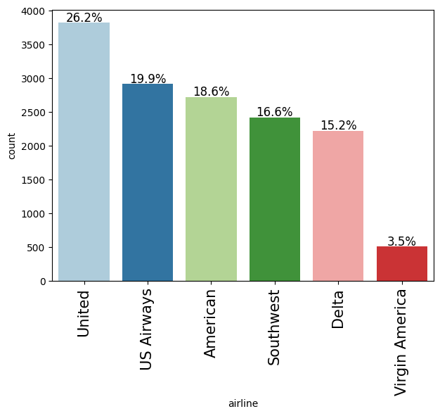

```python
# Plot the distribution of all tweets among each airline
labeled_barplot(df, 'airline', perc=True)
```

- United Airlines tweets make up the largest share (26%) of the tweets followed by US Airways (20%).
- Virgin America has the least number of tweets (3.5%).

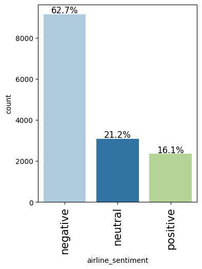

```python
# Plot the distribution of sentiment across all the tweets
labeled_barplot(df, 'airline_sentiment', perc=True)
```

- A majority (62.7%) of tweets are negative.
- There are only a few (16.1%) positive reviews.
- The dataset is imbalanced.

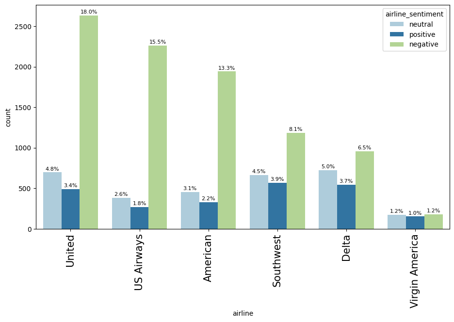

```python
# Plot the distribution of sentiment of tweets for each airline for whole data
labeled_barplot(df, 'airline', feature2='airline_sentiment',perc=True,size=8,n=10,height=6)
```

- Negative tweets make up most of each airline's sentiment, followed by neutral, then positve.
- Customers are more likely to post a tweet when they feel strongly negatively about something vs. positively.

```
United
```

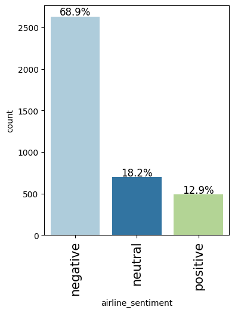

```
US Airways
```

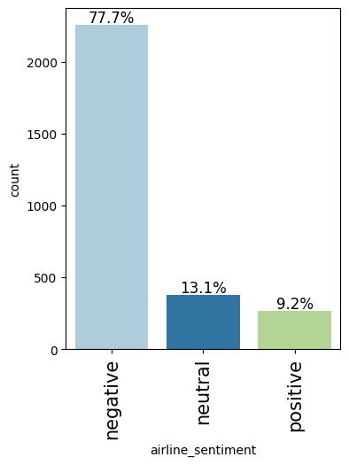

```
American
```

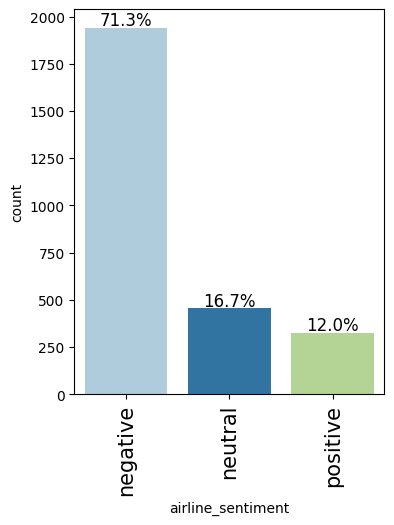

```
Southwest
```

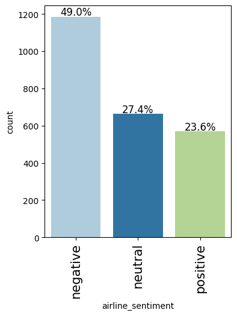

```
Delta
```

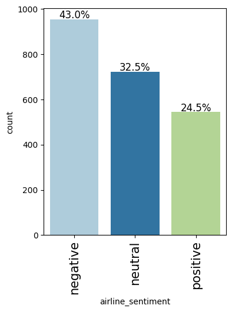

```
Virgin America
```

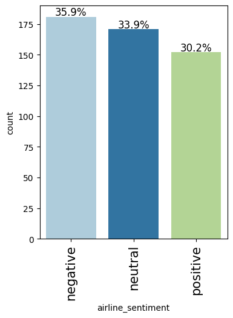

```python
# Plot the distribution of sentiment of tweets for each airline separately
flights=df.airline.value_counts().index
for i in flights:
  print(i)
  df_flight=df[df.airline==i]
  labeled_barplot(df_flight,'airline_sentiment',perc=True)
  plt.show()
  print(
        " ****************************************************************** "
    )  ## To create a separator
```

- United, US Airways, and American have much more negative than positive tweets (difference of greater than 55%).
- Southwest and Delta are more balanced between negative and positive tweets (difference of less than 26%).
- Virgin America has the least difference between negative and positive tweets, but it also had the fewest number of tweets.
- US Airways has the largest difference in distribution between negative and positive tweets (68.5%), even though it has the second highest number of tweets.

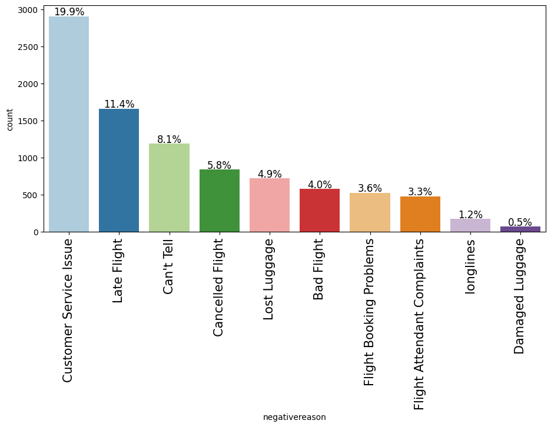

```python
# Plot the distribution of the negative reasons across all airlines
labeled_barplot(df,'negativereason',perc=True)
```

- Customer Service Issue is the top negative reason and makes up 19.9% of tweets.
- Damaged luggage and long lines are the least likely negative reasons.

```
United
```

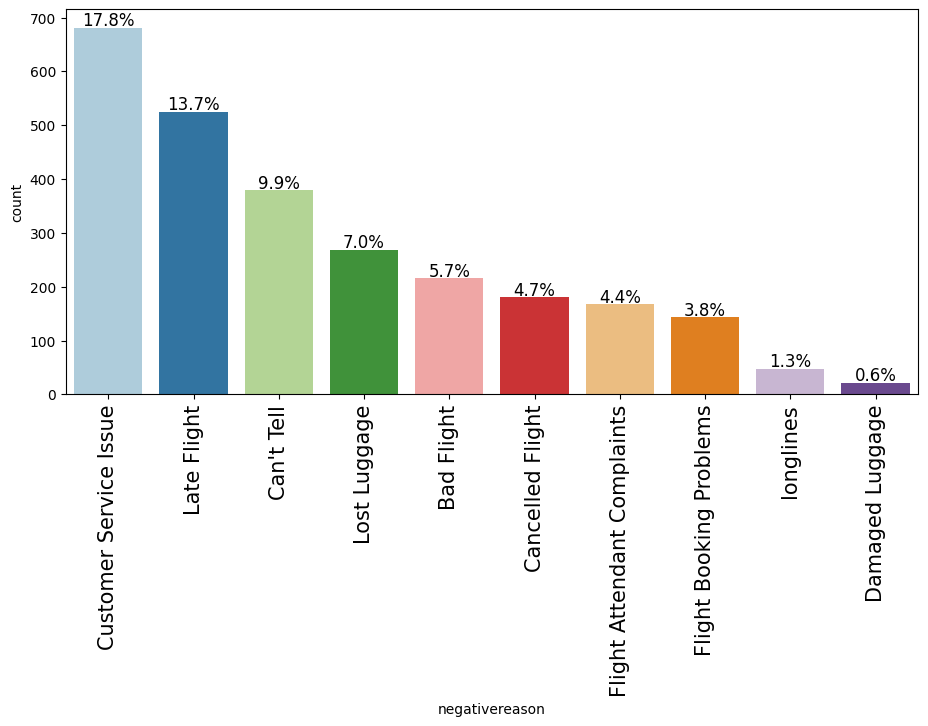

```
US Airways
```

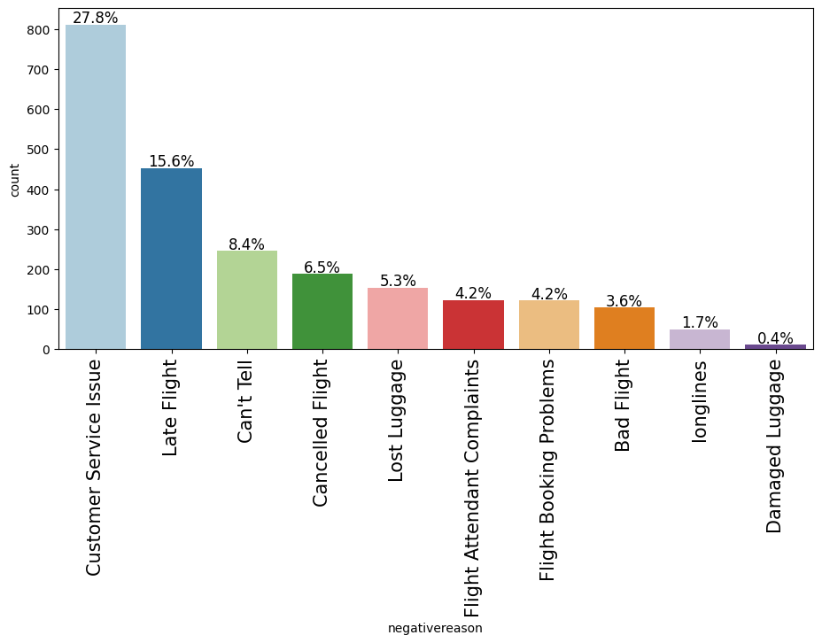

```
American
```

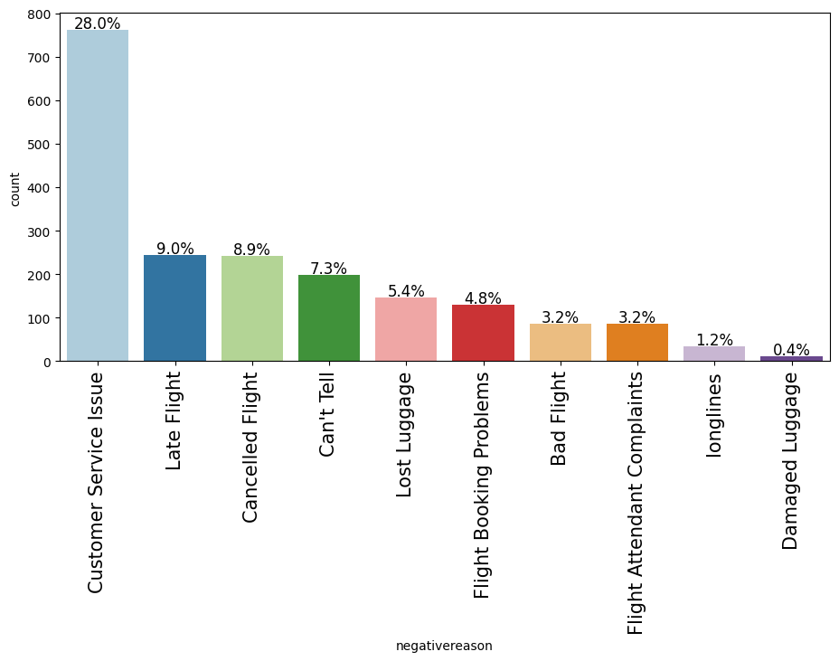

```
Southwest
```

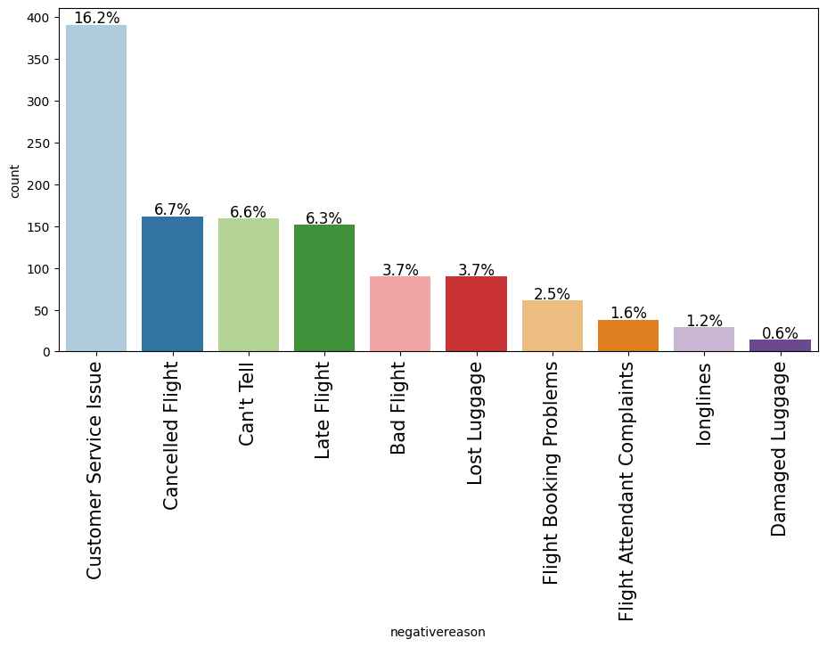

```
Delta
```

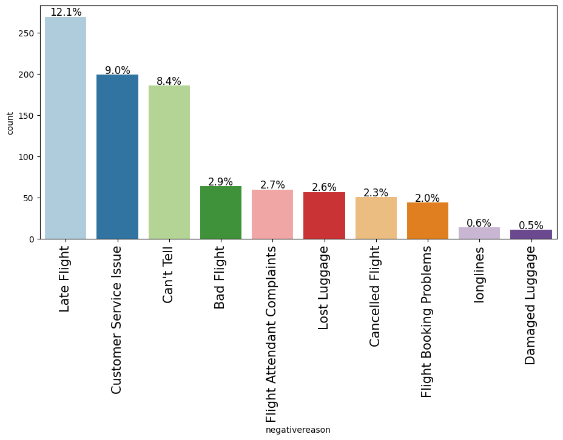

```
Virgin America
```

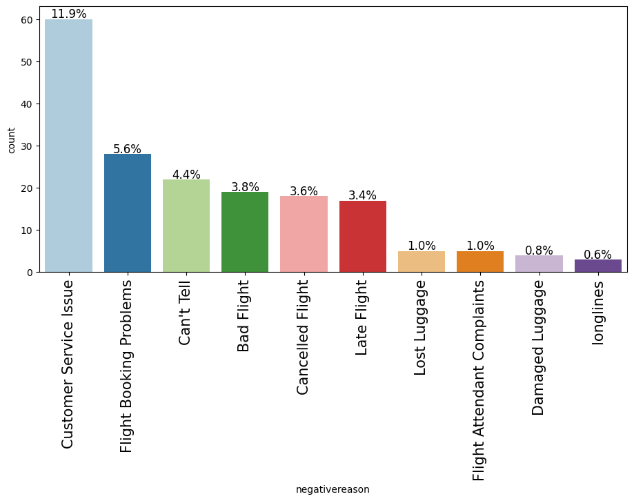

```python
# Plot the distribution of the negative reasons for each airline
flights=df.airline.value_counts().index
for i in flights:
  print(i)
  df_flight=df[df.airline==i]
  labeled_barplot(df_flight,'negativereason',perc=True)
  plt.show()
  print(
        " ****************************************************************** "
    )  ## To create a separator
```

- All airlines except Delta have "Customer Service Issue" as their main negative reason. Delta has it as its second reason.
- A late flight is a top 2 negative reason for United, US Airways, American and Delta.
- A cancelled flight and flight booking problems was the second major negative reason for Southwest and Virgin America, respectively.
- All airlines had a negative reason related to the flight in their top 2 either with a late flight, cancelled flight, or a flight booking.
- Damaged luggage and long lines were the least likely to be negative reasons across all airlines.

Plot the word cloud graph of tweets for positive and negative sentiment separately

```python
# Creating word cloud for negative tweets
# Extracting the negative tweets
negative_tweets = df[df['airline_sentiment'] == 'negative']

# joining the negative tweets using space seperator, helps to convert the all rows into one string
words = ' '.join(negative_tweets['text'])

# helps to remove the \n characters from the previous output
cleaned_word = " ".join([word for word in words.split()])

# creating the wordcloud using the WordCloud() method
wordcloud = WordCloud(stopwords = STOPWORDS,
                      colormap = 'RdBu',
                      background_color = 'white',
                      width = 3000,
                      height = 2500
                     ).generate(cleaned_word) # The generate() function takes one argument of the text we created, helps to generate the wordcloud
```

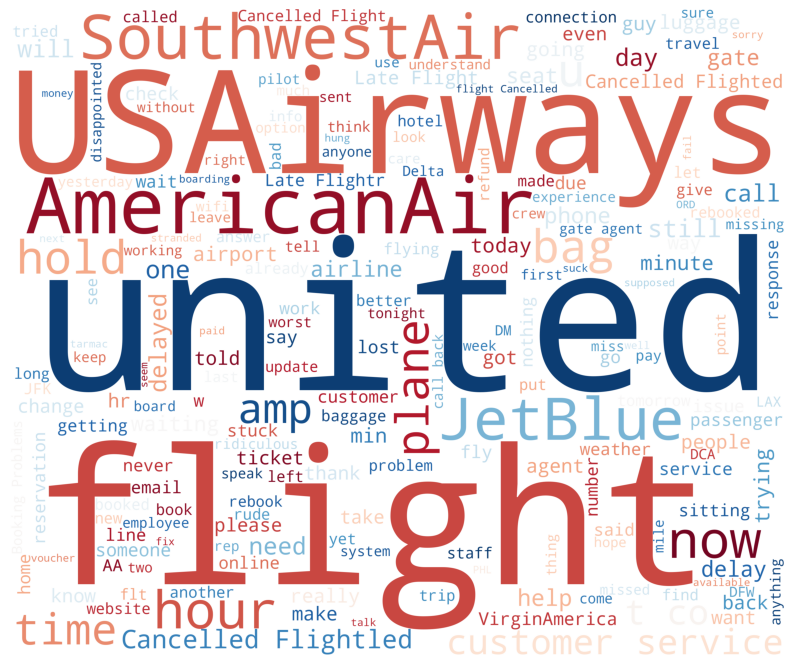

```python
# Plotting word cloud for negative tweets
plt.figure(1, figsize = (10, 10))

# Using the .imshow() method of matplotlib.pyplot to display the Word Cloud as an image.
plt.imshow(wordcloud)
plt.axis('off')
plt.show()
```

- Outside of the airline names, **hour, customer service, hold, cancelled flight, still, delay** were some of the important recurring words observed in the negative tweets.
- There are more words associated with delays and waiting for the negative tweets.

```python
# Creating word cloud for positive tweets
# Extracting the positive tweets
positive_tweets = df[df['airline_sentiment'] == 'positive']

# joining the positive tweets using space seperator, helps to convert the all rows into one string
words = ' '.join(positive_tweets['text'])

# helps to remove the \n characters from the previous output
cleaned_word = " ".join([word for word in words.split()])

# creating the wordcloud using the WordCloud() method
wordcloud = WordCloud(stopwords = STOPWORDS,
                      colormap = 'RdBu',
                      background_color = 'white',
                      width = 3000,
                      height = 2500
                     ).generate(cleaned_word) # The generate() function takes one argument of the text we created, helps to generate the wordcloud
```

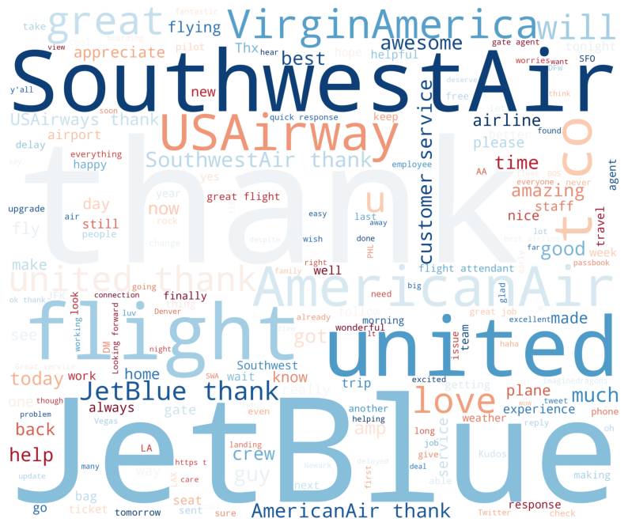

```python
# plotting word cloud for positive tweets
plt.figure(1, figsize = (10, 10))

# Using the .imshow() method of matplotlib.pyplot to display the Word Cloud as an image.
plt.imshow(wordcloud)
plt.axis('off')
plt.show()
```

- Outside of the airline names, **great, love, much, thank, appreciate, good, amazing** were some of the important recurring words observed in the positive tweets.
- There are more words associated with gratefulness and appreciation in the positive tweets.

## Part 3: Data Pre-Processing

We will drop unnecesary columns before text pre-processing.

```python
# drop all columns except text and sentiment
df1 = df[['text','airline_sentiment']]
```

```python
# check shape of data
print(f"There are {df1.shape[0]} rows and {df1.shape[1]} columns in the data.")
```

```
There are 14604 rows and 2 columns in the data.
```

```python
# check columns
df1.info()
```

```
<class 'pandas.core.frame.DataFrame'>
RangeIndex: 14604 entries, 0 to 14603
Data columns (total 2 columns):
 #   Column             Non-Null Count  Dtype
---  ------             --------------  -----
 0   text               14604 non-null  object
 1   airline_sentiment  14604 non-null  object
dtypes: object(2)
memory usage: 228.3+ KB
```

- There are only the text and airline_sentiment columns left in the data, as all other columns were unnecessary.
- There are no missing values in these columns.

Before going to model building we should have to clean the data for the better model performance.

```python
# View original data
df1.head()
```

|  | text | airline_sentiment |
| --- | --- | --- |
| 0 | @VirginAmerica What @dhepburn said. | neutral |
| 1 | @VirginAmerica plus you've added commercials to the experience... tacky. | positive |
| 2 | @VirginAmerica I didn't today... Must mean I need to take another trip! | neutral |
| 3 | @VirginAmerica it's really aggressive to blast obnoxious "entertainment" in your guests' faces &amp; they have little recourse | negative |
| 4 | @VirginAmerica and it's a really big bad thing about it | negative |

```python
# string pre-processing
def strip_html(text):
    """Remove HTML tags in string of text"""
    soup = BeautifulSoup(text, "html.parser")
    return soup.get_text()

def replace_contractions(text):
    """Replace contractions in string of text"""
    return contractions.fix(text)

def remove_numbers(text):
    """Remove numbers in string of text"""
    text = re.sub(r'\d+', '', text)
    return text

def remove_mentions(text):
    """Remove mentions from list of tokenized words"""
    text = re.sub("@[A-Za-z0-9]+","",text)
    return text

def clean_text(text):
    text = strip_html(text)
    text = replace_contractions(text)
    text = remove_numbers(text)
    text = remove_mentions(text)
    return text

df1['text'] = df1['text'].apply(lambda x: clean_text(x))

df1.head()
```

|  | text | airline_sentiment |
| --- | --- | --- |
| 0 | What said. | neutral |
| 1 | plus you have added commercials to the experience... tacky. | positive |
| 2 | I did not today... Must mean I need to take another trip! | neutral |
| 3 | it is really aggressive to blast obnoxious "entertainment" in your guests' faces & they have little recourse | negative |
| 4 | and it is a really big bad thing about it | negative |

```python
# Tokenization of data
df1['text'] = df1.apply(lambda row: nltk.word_tokenize(row['text']), axis=1)
df1.head()
```

|  | text | airline_sentiment |
| --- | --- | --- |
| 0 | [What, said, .] | neutral |
| 1 | [plus, you, have, added, commercials, to, the, experience, ..., tacky, .] | positive |
| 2 | [I, did, not, today, ..., Must, mean, I, need, to, take, another, trip, !] | neutral |
| 3 | [it, is, really, aggressive, to, blast, obnoxious, ``, entertainment, '', in, your, guests, ', faces, &, they, have, little, recourse] | negative |
| 4 | [and, it, is, a, really, big, bad, thing, about, it] | negative |

```python
# Defining stopwords
stopwords_list = stopwords.words('english')

customlist = ['not', "couldn't", 'didn', "didn't", 'doesn', "doesn't", 'hadn', "hadn't", 'hasn',
        "hasn't", 'haven', "haven't", 'isn', "isn't", 'ma', 'mightn', "mightn't", 'mustn',
        "mustn't", 'needn', "needn't", 'shan', "shan't", 'shouldn', "shouldn't", 'wasn',
        "wasn't", 'weren', "weren't", 'won', "won't", 'wouldn', "wouldn't"]

# Set custom stopwords list as not, couldn't etc. Words matter in Sentiment, so not removing them from original data.

stopwords_list = list(set(stopwords_list) - set(customlist))
```

```python
# pre-processing steps
def remove_non_ascii(words):
    """Remove non-ASCII characters from list of tokenized words"""
    new_words = []
    for word in words:
        new_word = unicodedata.normalize('NFKD', word).encode('ascii', 'ignore').decode('utf-8', 'ignore')
        new_words.append(new_word)
    return new_words

def remove_punctuation(words):
    """Remove punctuation from list of tokenized words"""
    new_words = []
    for word in words:
        new_word = re.sub(r'[^\w\s]', '', word)
        if new_word != '':
            new_words.append(new_word)
    return new_words

def remove_stopwords(words):
    """Remove stop words from list of tokenized words"""
    new_words = []
    for word in words:
      if word not in stopwords_list:
            new_words.append(word)
    return new_words

def to_lowercase(words):
    """Convert all characters to lowercase from list of tokenized words"""
    new_words = []
    for word in words:
        if word not in stopwords_list:
            new_words.append(word)
    return new_words

# apply lemmatization
lemmatizer = WordNetLemmatizer()
def lemmatize_list(words):
    new_words = []
    for word in words:
      new_words.append(lemmatizer.lemmatize(word, pos='v'))
    return new_words

# bring all functions together
def normalize(words):
    words = remove_non_ascii(words)
    words = remove_punctuation(words)
    words = to_lowercase(words)
    words = remove_stopwords(words)
    words = lemmatize_list(words)
    return ' '.join(words)

df1['text'] = df1.apply(lambda row: normalize(row['text']), axis=1)
df1.head()
```

|  | text | airline_sentiment |
| --- | --- | --- |
| 0 | What say | neutral |
| 1 | plus add commercials experience tacky | positive |
| 2 | I not today Must mean I need take another trip | neutral |
| 3 | really aggressive blast obnoxious entertainment guests face little recourse | negative |
| 4 | really big bad thing | negative |

## Part 4: Text Vectorization

### Part 4a: CountVectorizer

```python
# CountVectorizer
# Vectorization (Convert text data to numbers).
bow_vec = CountVectorizer(max_features=500)                # Keep only 500 features as number of features will increase the processing time.
data_features = bow_vec.fit_transform(df1['text'])

data_features = data_features.toarray()                        # Convert the data features to array.
```

```python
# Label X and y
X = data_features

y = df1.airline_sentiment
```

```python
# Split data into training and testing set.
X_train, X_test, y_train, y_test = train_test_split(X, y, test_size=0.3, random_state=42)
```

```python
# Finding optimal number of base learners using k-fold CV ->
base_ln = np.arange(10,400,50).tolist()
base_ln
```

```
[10, 60, 110, 160, 210, 260, 310, 360]
```

```python
# K-Fold Cross - validation
cv_scores = []
for b in base_ln:
    clf = RandomForestClassifier(n_estimators = b)
    scores = cross_val_score(clf, X_train, y_train, cv = 5, scoring = 'accuracy')
    cv_scores.append(scores.mean())
print(cv_scores)
```

```
[0.7283319537414055, 0.7429074780262106, 0.7451570103206235, 0.7451567232379102, 0.7470161101249289, 0.7463314657007928, 0.7467224245092081, 0.7466245771510869]
```

- The cross validation scores range from 73% to 75%.

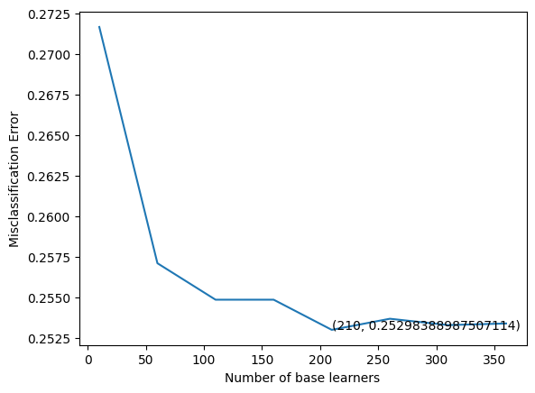

```python
# plotting the error as k increases
error = [1 - x for x in cv_scores]                                 #error corresponds to each nu of estimator
optimal_learners = base_ln[error.index(min(error))]                #Selection of optimal nu of n_estimator corresponds to minimum error.
plt.plot(base_ln, error)                                           #Plot between each nu of estimator and misclassification error
xy = (optimal_learners, min(error))
plt.annotate('(%s, %s)' % xy, xy = xy, textcoords='data')
plt.xlabel("Number of base learners")
plt.ylabel("Misclassification Error")
plt.show()
```

```python
# Training the best model and calculating accuracy on test data
clf = RandomForestClassifier(n_estimators = optimal_learners)
clf.fit(X_train, y_train)
clf.score(X_test, y_test)
count_vectorizer_predicted = clf.predict(X_test)
print(classification_report(y_test ,count_vectorizer_predicted ))
print("Accuracy of the model is : ",accuracy_score(y_test,count_vectorizer_predicted))
```

```
              precision    recall  f1-score   support

    negative       0.83      0.89      0.86      2796
     neutral       0.58      0.51      0.54       885
    positive       0.71      0.62      0.66       701

    accuracy                           0.77      4382
   macro avg       0.71      0.67      0.69      4382
weighted avg       0.76      0.77      0.76      4382

Accuracy of the model is :  0.7676859881332725
```

```
[[2475  233   88]
 [ 342  453   90]
 [ 171   94  436]]
```

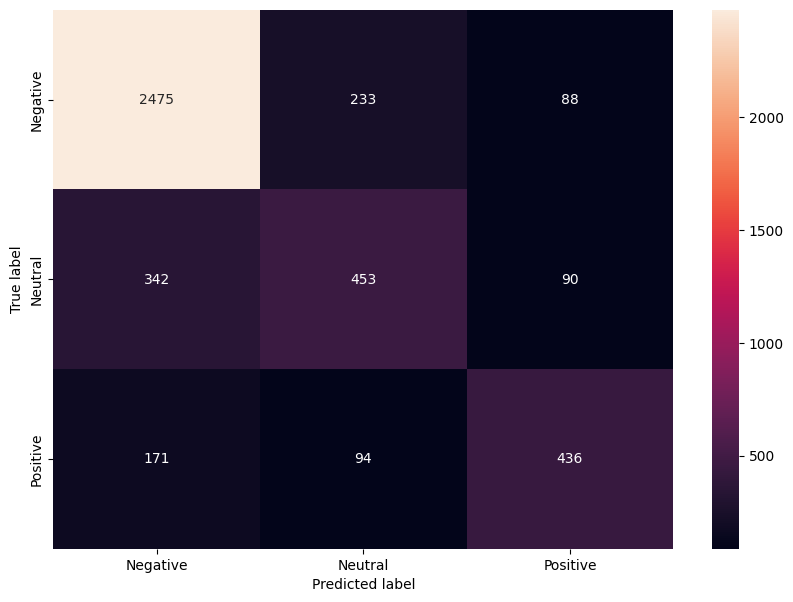

```python
# Print and plot Confusion matirx to get an idea of how the distribution of the prediction is, among all the classes.
conf_mat = confusion_matrix(y_test, count_vectorizer_predicted)

print(conf_mat)

df_cm = pd.DataFrame(conf_mat, index = [i for i in ['Negative', 'Neutral','Positive']],
                  columns = [i for i in ['Negative', 'Neutral','Positive']])
plt.figure(figsize = (10,7))
sns.heatmap(df_cm, annot=True, fmt='g')
plt.ylabel("True label")
plt.xlabel("Predicted label")
```

- Accuracy is at 76.8%, so the model is not overfitting.
- All metrics are the highest for negative tweets and lowest for neutral tweets.
- Precision and recall scores are close in value for each sentiment type.

```
thank,not,thanks,great,http,delay,flight,hours,love,get,hold,cancelled,call,wait,bag,would,hour,awesome,best,time,fly,please,customer,go,service,help,good,make,like,know,airline,need,one,still,worst,amaze,never,us,can,you,
```

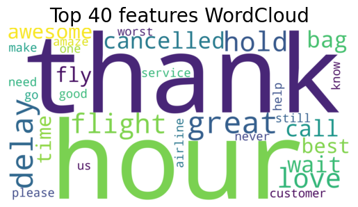

```python
# plot Word Cloud of top features
all_features = bow_vec.get_feature_names_out()              #Instantiate the feature from the vectorizer
top_features=''                                            # Addition of top 40 feature into top_feature after training the model
feat=clf.feature_importances_
features=np.argsort(feat)[::-1]
for i in features[0:40]:
    top_features+=all_features[i]
    top_features+=','

print(top_features)

print(" ")
print(" ")

wordcloud = WordCloud(background_color="white",colormap='viridis',width=2000,
                          height=1000).generate(top_features)

# Display the generated image:
plt.imshow(wordcloud, interpolation='bilinear')
plt.figure(1, figsize=(14, 11), frameon='equal')
plt.title('Top 40 features WordCloud', fontsize=20)
plt.axis("off")
plt.show()
```

- The top words have positive and negative sentiment like thanks, great and delay, hours.

### Part 4b: TF-IDF Vectorizer

```python
# Using TfidfVectorizer to convert text data to numbers.
tfidf_vect = TfidfVectorizer(max_features=500)
tfidf_features = tfidf_vect.fit_transform(df1['text'])

tfidf_features = tfidf_features.toarray()

tfidf_features.shape     #feature shape
```

```
(14604, 500)
```

```python
# Label X and y
X = tfidf_features

y = df1.airline_sentiment
```

```python
# Split data into training and testing set.
X_train, X_test, y_train, y_test = train_test_split(X, y, test_size=0.3, random_state=42)
```

```python
# Finding optimal number of base learners using k-fold CV ->
base_ln = np.arange(10,400,50).tolist()
base_ln
```

```
[10, 60, 110, 160, 210, 260, 310, 360]
```

```python
# K-Fold Cross - validation
cv_scores_tfidf = []
for b in base_ln:
    clf = RandomForestClassifier(n_estimators = b)
    scores = cross_val_score(clf, X_train, y_train, cv = 5, scoring = 'accuracy')
    cv_scores_tfidf.append(scores.mean())
print(cv_scores_tfidf)
```

```
[0.7396793286092278, 0.752591160723257, 0.7549393059296934, 0.7540589667893147, 0.7545480121914458, 0.7540591581777903, 0.7555265814668969, 0.756602328240805]
```

- The cross validation scores range from 74% to 76%.

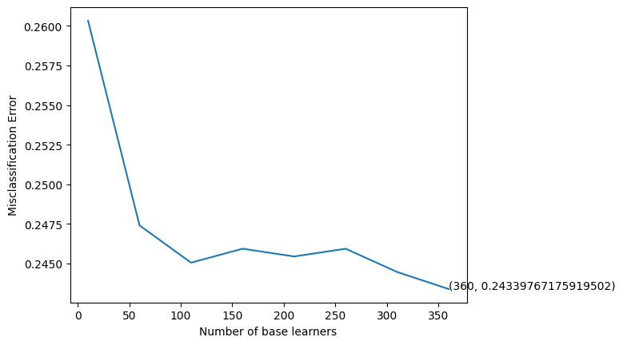

```python
# plotting the error as k increases
error = [1 - x for x in cv_scores_tfidf]                                 #error corresponds to each nu of estimator
optimal_learners = base_ln[error.index(min(error))]                #Selection of optimal nu of n_estimator corresponds to minimum error.
plt.plot(base_ln, error)                                           #Plot between each nu of estimator and misclassification error
xy = (optimal_learners, min(error))
plt.annotate('(%s, %s)' % xy, xy = xy, textcoords='data')
plt.xlabel("Number of base learners")
plt.ylabel("Misclassification Error")
plt.show()
```

```python
# Training the best model and calculating accuracy on test data
clf_tfidf = RandomForestClassifier(n_estimators = optimal_learners)
clf_tfidf.fit(X_train, y_train)
clf_tfidf.score(X_test, y_test)
tfidf_predicted = clf_tfidf.predict(X_test)
print(classification_report(y_test ,tfidf_predicted ))
print("Accuracy of the model is : ",accuracy_score(y_test,tfidf_predicted))
```

```
              precision    recall  f1-score   support

    negative       0.82      0.92      0.87      2796
     neutral       0.63      0.49      0.55       885
    positive       0.74      0.59      0.65       701

    accuracy                           0.78      4382
   macro avg       0.73      0.66      0.69      4382
weighted avg       0.77      0.78      0.77      4382

Accuracy of the model is :  0.7788680967594706
```

```
[[2571  160   65]
 [ 374  431   80]
 [ 201   89  411]]
```

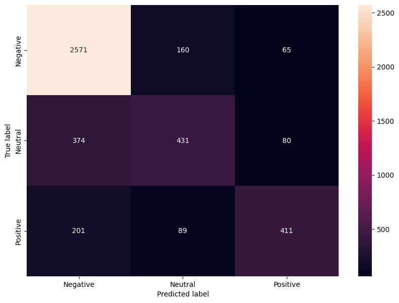

```python
# Print and plot Confusion matirx to get an idea of how the distribution of the prediction is, among all the classes.
conf_mat_tfidf = confusion_matrix(y_test, tfidf_predicted)

print(conf_mat_tfidf)

df_cm_tfidf = pd.DataFrame(conf_mat_tfidf, index = [i for i in ['Negative', 'Neutral','Positive']],
                  columns = [i for i in ['Negative', 'Neutral','Positive']])
plt.figure(figsize = (10,7))
sns.heatmap(df_cm_tfidf, annot=True, fmt='g')
plt.ylabel("True label")
plt.xlabel("Predicted label")
```

- Accuracy of the model improved to 77.9%, and the model is not overfitting.
- All metrics are highest for the negative tweets and lowest for the neutral tweets.
- The macro average recall decreased from 0.67 to 0.66, but other metrics are the same or improved.
- Recall decreased for the neutral and positive tweets, but improved for the negative tweets.

```
thank,not,thanks,http,flight,great,delay,love,get,hours,cancelled,hold,fly,wait,awesome,call,good,dm,bag,would,time,best,follow,service,hour,please,customer,know,airline,need,appreciate,go,amaze,make,help,can,one,tomorrow,still,us,
```

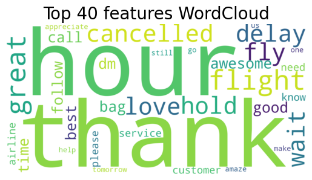

```python
# plot Word Cloud of top features
all_features_tfidf = tfidf_vect.get_feature_names_out()              #Instantiate the feature from the vectorizer
top_features_tfidf=''                                            # Addition of top 40 feature into top_feature after training the model
feat_tfidf=clf_tfidf.feature_importances_
features_tfidf=np.argsort(feat_tfidf)[::-1]
for i in features_tfidf[0:40]:
    top_features_tfidf+=all_features_tfidf[i]
    top_features_tfidf+=','

print(top_features_tfidf)

print(" ")
print(" ")

wordcloud = WordCloud(background_color="white",colormap='viridis',width=2000,
                          height=1000).generate(top_features_tfidf)

# Display the generated image:
plt.imshow(wordcloud, interpolation='bilinear')
plt.figure(1, figsize=(14, 11), frameon='equal')
plt.title('Top 40 features WordCloud', fontsize=20)
plt.axis("off")
plt.show()
```

- Many of the top words are similar like thanks, great, delay, and love.
- Both negative and positive sentiment words are present.

Comparing the accuracies of Supervised Learning methods i.e Count Vectorizer and TF-IDF

```python
#convert the test samples into a dataframe where the columns are
#the y_test(ground truth labels),tf-idf model predicted labels(tfidf_predicted),Count Vectorizer model predicted labels(count_vectorizer_predicted)
df2 = pd.DataFrame(y_test.tolist(),columns =['y_test'])
df2['count_vectorizer_predicted'] = count_vectorizer_predicted
df2['tfidf_predicted'] = tfidf_predicted
df2.head()
```

|  | y_test | count_vectorizer_predicted | tfidf_predicted |
| --- | --- | --- | --- |
| 0 | neutral | neutral | neutral |
| 1 | negative | negative | negative |
| 2 | negative | negative | negative |
| 3 | negative | negative | negative |
| 4 | negative | negative | negative |

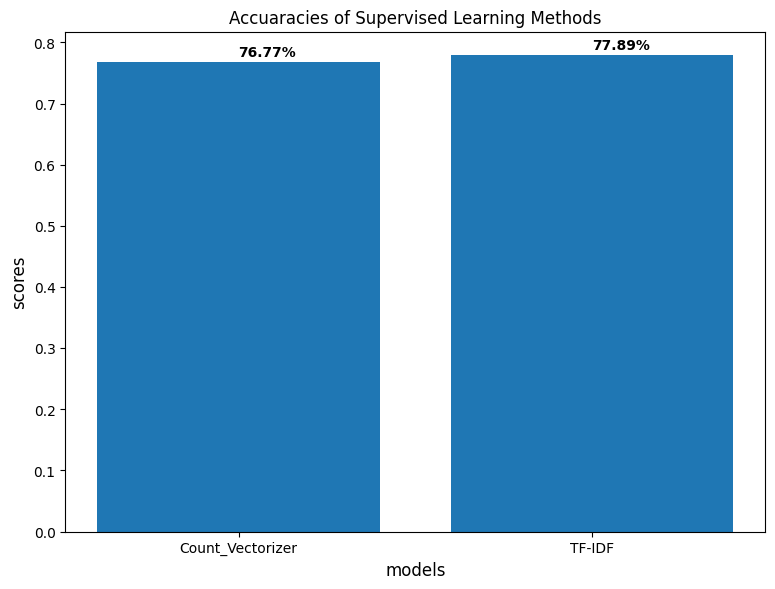

```python
#create bar plot to compare the accuaracies of Count Vectorizer and TF-IDF
fig = plt.figure(figsize=(7,5))
ax = fig.add_axes([0,0,1,1])
subjects = ['Count_Vectorizer', 'TF-IDF']

# calculation accuracies of Count Vectorizer and TF-IDF using accuracy_score metrics
scores = [accuracy_score(y_test,count_vectorizer_predicted),accuracy_score(y_test,tfidf_predicted)]
ax.bar(subjects,scores)
ax.set_ylabel('scores',fontsize= 12)    # y axis label
ax.set_xlabel('models',fontsize= 12)    # x axis label
ax.set_title('Accuaracies of Supervised Learning Methods')  # tittle
for i, v in enumerate(scores):
    ax.text( i ,v+0.01, '{:.2f}%'.format(100*v), color='black', fontweight='bold')
    plt.savefig('barplot_1.png',dpi=100, format='png', bbox_inches='tight')
plt.show()
```

- The results are similar for both models.
- **TF-IDF shows a better performance than Count Vectorizer**, because it not only focuses on the frequency of words present in the corpus but also provides the importance of the words. We can then remove the words that are less important for analysis, hence making the model building less complex by reducing the input dimensions.

## Part 5: Summary and Recommendations

**Data Background:**

- There are 14640 rows and 15 columns in the data.
- There are 36 duplicated rows in the data.
- The columns airline_sentiment and text are object type.

**Data Preprocessing:**

**Observations from EDA:**

- United Airlines tweets make up the largest share (26%) of the tweets and Virgin America has the least number of tweets (3.5%).
- A majority (62.7%) of tweets are negative, followed by neutral and positive. The data is imbalanced.
- United, US Airways, and American have much more negative than positive tweets (difference of greater than 55%).
- Southwest and Delta are more balanced between negative and positive tweets (difference of less than 26%).
- All airlines except Delta have "Customer Service Issue" as their main negative reason. Delta has it as its second reason.
- All airlines had a negative reason related to the flight in their top 2 either with a late flight, cancelled flight, or a flight booking.
- Damaged luggage and long lines were the least likely to be negative reasons across all airlines.
- Outside of the airline names, the hour, late flight, hold, waiting, still, delay were some of the important recurring words observed in the negative tweets.
- Outside of the airline names, the great, love, much, thank, appreciate, good, amazing were some of the important recurring words observed in the positive tweets.

**Vectorization, Model Building and Performance:**

- Data was split into train (70%) test (30%) sets.
- The pre-processed data is converted to numbers (vectorized), so that we can feed the data into the model.
- Random Forest classifier was built on the data. Count Vectorizer showed a 76.8% accuracy on the test data. TF-IDF vectorizer showed a 77.9% accuracy on the test data. Both models did not overfit.
- All metrics are the highest for negative tweets and lowest for neutral tweets. It is easier for the model to classify a positive or negative sentiment than a neutral one.
- In supervised learning techniques, TF-IDF outperforms BoW since it not only considers the frequency of words in the corpus but also considers their importance.
- TFIDF technique was able to give improved f1 scores for negative and neutral tweets. The f1 score for positive tweets was low compared to the f1 score given by the model through bag of words vectors.

### Recommendations

- Customers are more likely to tweet when they feel negatively than positively.
- Airlines should focus on improving customer service issues. More research into the data on what the exact customer issues are can improve positive sentiment.
- Airlines should focus on minimizing cancellation and delay of flights.
- Airlines can focus less on problems due to luggage or long lines.
- Words of appreciation were the top words for positive sentiment tweets. Airlines should focus on compensation for customers or offering rewards when appropriate.
- It is recommended to train the model with more balanced data such as using oversampling or undersampling techniques to improve performance on positive sentiment tweets.
- We can still increase the accuracy of our model by increasing the max_feature parameter in the vectorizer.
- We can apply other model tuning and hyperparameter tuning techniques, as well as other pre-processing techniques to increase the overall accuracy even further.